# Eight Views of a Playtest

What you will be able to build by the end of these notes

## Ten questions R can answer

These are the questions that come up in the week after a playtest. None of them is exotic. All of them are painful to answer with a spreadsheet, and each one is answered below by a single figure and a few dozen lines of R.

| The question you are actually asking | Answered by |
| --- | --- |
| I have 120 rows of results and no idea what is in them. Where do I start? | View 1 |
| All four characters average about the same score. Does that mean they are balanced? | View 2 |
| I designed four classes to play differently. Did they stay different once real people played them? | View 3 |
| I want players to score higher. Which ability is actually worth buffing? | View 4 |
| Testers keep giving up partway through. When do I lose them, and is it the same moment every time? | View 5 |
| The survey came back with 960 ratings across eight questions. Which complaint do I fix first? | View 6 |
| My frame-rate counter says 60 FPS. My testers say the game stutters. Who is lying? | View 7 |
| How can I find where players are loitering, sniping, or being funnelled into a kill zone? | View 8 |
| Which parts of my level is nobody using? | View 8 |
| How did one particular player move through the level — did they learn the route, or wander? | View 8b |

Every one of these is a question about **your own game**, asked of data your own engine can already record. The only thing missing is the ability to read it.

## Before you read any code

This document is a **showcase**, not a lesson. Nothing here is examinable and you are not expected to understand the code yet. Its only job is to show you what a few months of R can do to a pile of raw playtest numbers.

Every figure below was produced from 5 CSV files, in chunks of between 11 and 55 lines of code. By the end of these notes you will be able to answer the first seven questions with base R, dplyr and ggplot2, producing plainer, static versions of the plots shown here. The three movement questions in View 8 use position data that stays in this showcase. The polish on this page is the destination, not the syllabus.

**To begin the notes, go to Start Here.** It explains the four stages of the course, from October to March, and how the notes, labs and reference pages fit together.

**NoteThe data**

*Tidebreak* is a fictional four-player top-down arena, used here so that the example is self-contained. The playtest recorded four things:

| File | One row per | Holds |
| --- | --- | --- |
| `tidebreak_sessions.csv` | player, per session | Six end-of-match ability ratings, match statistics, wrong turns, items collected, whether the session was completed, session length, quit reason, difficulty and enjoyment ratings, and a one-line comme… |
| `tidebreak_survey.csv` | player, per session | Eight agreement items rated 1 to 5 |
| `tidebreak_frame_times.csv` | rendered frame | Frame time in milliseconds, by build and level zone |
| `tidebreak_positions.csv` | player, per second | Top-down position for eight players across one 180-second match |

All four are synthetic, but they behave like the real thing: the numbers are messy, the interesting findings are not the obvious ones, and at least two widely held assumptions about the game turn out to be wrong.

```r
library(tidyverse)
library(plotly)
library(DT)

# Five files from one playtest. Everything below comes from these.
sessions    <- read_csv("data/tidebreak_sessions.csv")
survey      <- read_csv("data/tidebreak_survey.csv")
frame_times <- read_csv("data/tidebreak_frame_times.csv")
positions   <- read_csv("data/tidebreak_positions.csv")
level       <- read_csv("data/tidebreak_level.csv")

# A handful of colours, used everywhere. Fewer colours, fewer things to learn.
pal <- c(blue = "#2a78d6", orange = "#eb6834", aqua = "#1baf7a", yellow = "#eda100")
ink <- c(primary = "#0b0b0b", secondary = "#52514e", grid = "#e6e5e1")

# Each archetype keeps its colour in every view, so blue always means Scout.
arch_pal <- c(Scout = pal[["blue"]],  Sentinel = pal[["orange"]],
              Engineer = pal[["aqua"]], Duelist = pal[["yellow"]])

# Same idea for the two builds, which come back in Views 5 and 7.
build_pal <- c(A = pal[["orange"]], B = pal[["blue"]])

# One shared look for every chart, so the views read as one document.
theme_tb <- function() {
  theme_minimal(base_size = 12) +
    theme(
      plot.title      = element_text(face = "bold", colour = ink["primary"], size = 13),
      plot.subtitle   = element_text(colour = ink["secondary"], size = 11),
      axis.title      = element_text(colour = ink["secondary"], size = 10),
      axis.text       = element_text(colour = ink["secondary"]),
      panel.grid.minor = element_blank(),
      panel.grid.major = element_line(colour = ink["grid"], linewidth = 0.3),
      legend.position = "none"
    )
}
```

## View 1 — The table you can actually read

**Question: what happened in each session?**

Before you analyse anything you need to be able to look at your data. A raw CSV in Excel is awkward at 120 rows and unusable at 120,000. A rendered table is searchable and sortable, and it goes straight into a report.

Sort by **Score**, or type `Sentinel` into the search box, and you will already see the finding that View 2 makes formal.

```r
sessions %>%
  # Keep the ten columns a designer asks about first, with readable names.
  select(Session = session_id, Player = player_id, Cohort = cohort,
         Archetype = archetype, Build = build, Score = score,
         Kills = kills, Deaths = deaths, `Alive (s)` = time_alive_s,
         Awareness = awareness) %>%
  # datatable() turns it into a table you can search, sort and page through.
  datatable(
    rownames = FALSE,
    options  = list(pageLength = 8, dom = "ftip", scrollX = TRUE),
    caption  = "Tidebreak playtest: 120 sessions"
  ) %>%
  # A bar inside each Score cell, so high and low scores jump out as you scroll.
  formatStyle("Score",
    background = styleColorBar(range(sessions$score), "#cde2fb"),
    backgroundSize = "98% 60%", backgroundRepeat = "no-repeat",
    backgroundPosition = "center")
```

| Session | Player | Cohort | Archetype | Build | Score | Kills | Deaths | Alive (s) | Awareness |
| --- | --- | --- | --- | --- | --- | --- | --- | --- | --- |
| S001 | P01 | Regular | Scout | A | 1370 | 7 | 4 | 98 | 77 |
| S002 | P02 | Veteran | Scout | B | 1795 | 5 | 2 | 105 | 91 |
| S003 | P03 | Regular | Scout | A | 1690 | 5 | 2 | 115 | 74 |
| S004 | P04 | Novice | Scout | B | 1544 | 7 | 4 | 80 | 74 |
| S005 | P05 | Veteran | Scout | A | 2019 | 12 | 3 | 121 | 95 |
| S006 | P06 | Regular | Scout | B | 1614 | 7 | 5 | 115 | 87 |
| S007 | P07 | Veteran | Scout | A | 1652 | 6 | 4 | 118 | 83 |
| S008 | P08 | Novice | Scout | B | 1331 | 7 | 4 | 99 | 67 |
| S009 | P09 | Regular | Scout | A | 1632 | 7 | 3 | 103 | 79 |
| S010 | P10 | Regular | Scout | B | 1631 | 10 | 4 | 71 | 82 |

[output cut: 110 more lines]

## View 2 — Distributions, not averages

**Question: which archetype performs best?**

The tempting answer is to compare four average scores. Do that here and the archetypes look almost identical, which would be a design decision made on a misreading.

A violin plot draws the whole distribution. Read the **Sentinel** shape: it is not one hump but two. Sentinel runs either anchor the objective and score well, or collapse in the opening seconds and score badly. There is almost no middle. That is a balance problem an average would have hidden completely.

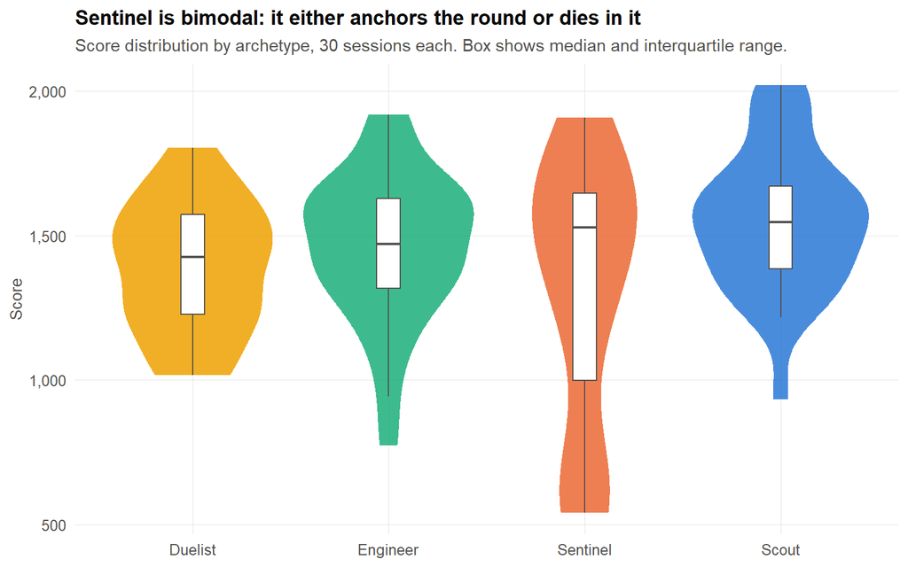

```r
sessions %>%
  # Order the archetypes by median score, weakest to strongest.
  mutate(archetype = fct_reorder(archetype, score, .fun = median)) %>%
  ggplot(aes(archetype, score, fill = archetype)) +
  # The violin is the whole distribution. Look at the Sentinel: two humps,
  # where an average would show you one.
  geom_violin(colour = NA, alpha = 0.85, width = 0.9) +
  geom_boxplot(width = 0.12, fill = "white", colour = ink[["secondary"]],
               outlier.shape = NA, linewidth = 0.4) +
  scale_fill_manual(values = arch_pal) +
  scale_y_continuous(labels = scales::comma) +
  # Put the finding in the title, so nobody has to work it out.
  labs(
    title    = "Sentinel is bimodal: it either anchors the round or dies in it",
    subtitle = "Score distribution by archetype, 30 sessions each. Box shows median and interquartile range.",
    x = NULL, y = "Score"
  ) +
  theme_tb()
```

## View 3 — Six numbers as a shape

**Question: are the four archetypes actually playing differently?**

Each session ends with six ability ratings on a 0–100 scale. Comparing four archetypes across six measures means twenty-four numbers, which no one can hold in their head. Drawn as a radar, each archetype becomes a shape you can recognise at a glance, and the grey outline behind each one is the all-player average for reference.

The shapes are distinct and they are roughly the shapes the design intended. That is the result you want from this chart: confirmation that the archetypes are not quietly converging on the same playstyle.

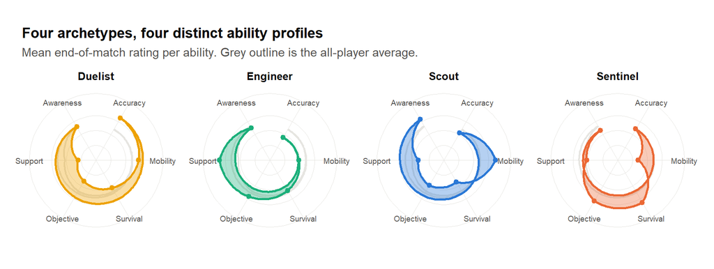

```r
metrics <- c("accuracy", "mobility", "survivability",
             "objective_control", "support", "awareness")

pretty <- c(accuracy = "Accuracy", mobility = "Mobility",
            survivability = "Survival", objective_control = "Objective",
            support = "Support", awareness = "Awareness")

# One row per archetype per ability, so every ability can sit on the same circle.
long <- sessions %>%
  select(archetype, all_of(metrics)) %>%
  pivot_longer(-archetype, names_to = "metric", values_to = "value") %>%
  mutate(metric = factor(pretty[metric], levels = unname(pretty)))

# The average for each archetype, and for everyone, to draw against.
by_arch <- long %>% group_by(archetype, metric) %>% summarise(value = mean(value))
overall <- long %>% group_by(metric) %>% summarise(value = mean(value))

ggplot() +
  # Grey outline: the all-player average. Coloured shape: one archetype.
  geom_polygon(data = overall, aes(metric, value, group = 1),
               fill = NA, colour = ink[["grid"]], linewidth = 0.8) +
  geom_polygon(data = by_arch,
               aes(metric, value, group = archetype, fill = archetype, colour = archetype),
               alpha = 0.35, linewidth = 0.9) +
  geom_point(data = by_arch, aes(metric, value, colour = archetype), size = 1.8) +
  # coord_polar() bends the axis into a circle. That is all a radar chart is.
  coord_polar(clip = "off") +
  facet_wrap(~archetype, nrow = 1) +
  scale_fill_manual(values = arch_pal) +
  scale_colour_manual(values = arch_pal) +
  scale_y_continuous(limits = c(0, 100), breaks = c(25, 50, 75)) +
  labs(
    title    = "Four archetypes, four distinct ability profiles",
    subtitle = "Mean end-of-match rating per ability. Grey outline is the all-player average.",
    x = NULL, y = NULL
  ) +
  theme_tb() +
  theme(axis.text.y   = element_blank(),
        axis.text.x   = element_text(size = 7),
        strip.text    = element_text(face = "bold", colour = ink[["primary"]]),
        panel.spacing = unit(1.6, "lines"),
        plot.margin   = margin(10, 20, 10, 20))
```

## View 4 — What actually drives score

**Question: which abilities and behaviours move the scoreboard?**

A correlogram puts every pair of variables in one picture. Blue means the two rise together, red means one rises as the other falls, and pale means no relationship at all.

Three things to read off it:

- **Awareness** is the strongest positive correlate of score. Map knowledge beats mechanical skill in this build.
- **Shots fired** is essentially uncorrelated with score. Players who shoot more do not win more, which contradicts what the team assumed.
- **Mobility** and **survivability** pull against each other, which is the intended trade-off working as designed.

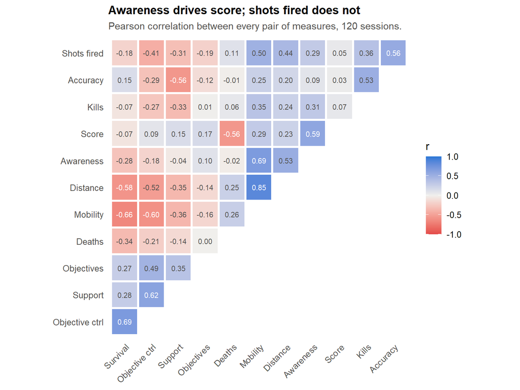

```r
vars <- c("accuracy", "mobility", "survivability", "objective_control",
          "support", "awareness", "shots_fired", "distance_m",
          "kills", "deaths", "objectives", "score")

nice <- c(accuracy = "Accuracy", mobility = "Mobility", survivability = "Survival",
          objective_control = "Objective ctrl", support = "Support",
          awareness = "Awareness", shots_fired = "Shots fired",
          distance_m = "Distance", kills = "Kills", deaths = "Deaths",
          objectives = "Objectives", score = "Score")

# Every measure correlated with every other one.
cm <- cor(sessions[vars])
# Sit measures that move together next to each other, so the clusters stand out.
ord <- hclust(as.dist(1 - cm))$order
lv  <- nice[vars[ord]]

cm_long <- as.data.frame(as.table(cm)) %>%
  setNames(c("a", "b", "r")) %>%
  mutate(a = factor(nice[as.character(a)], levels = lv),
         b = factor(nice[as.character(b)], levels = lv)) %>%
  filter(as.integer(a) < as.integer(b))   # keep one half: the other is a mirror image

ggplot(cm_long, aes(a, b, fill = r)) +
  geom_tile(colour = "white", linewidth = 1.2) +
  # Print each value. White text on the dark squares, so it stays readable.
  geom_text(aes(label = sprintf("%.2f", r),
                colour = abs(r) > 0.55), size = 2.9) +
  scale_fill_gradient2(low = "#e34948", mid = "#f0efec", high = "#2a78d6",
                       midpoint = 0, limits = c(-1, 1), name = "r") +
  scale_colour_manual(values = c(`TRUE` = "white", `FALSE` = ink[["secondary"]]),
                      guide = "none") +
  coord_fixed() +
  labs(
    title    = "Awareness drives score; shots fired does not",
    subtitle = "Pearson correlation between every pair of measures, 120 sessions.",
    x = NULL, y = NULL
  ) +
  theme_tb() +
  theme(axis.text.x       = element_text(angle = 45, hjust = 1),
        legend.position   = "right",
        panel.grid.major  = element_blank(),
        panel.grid.minor  = element_blank())
```

## View 5 — When people stop playing

**Question: we changed how the game explains its objective. Did it keep anyone?**

A retention curve shows what fraction of participants were still playing at each minute of the test. It is the shape that matters, not the endpoint: a smooth decay means people drifted away, a cliff means something specific pushed them out.

Now look at what a summary table would have told you: median session length is 23.2 minutes for Build A and 27.1 for Build B. That reads as a modest improvement. The curve shows something else — one specific, fixable moment where a fifth of the Build A testers gave up.

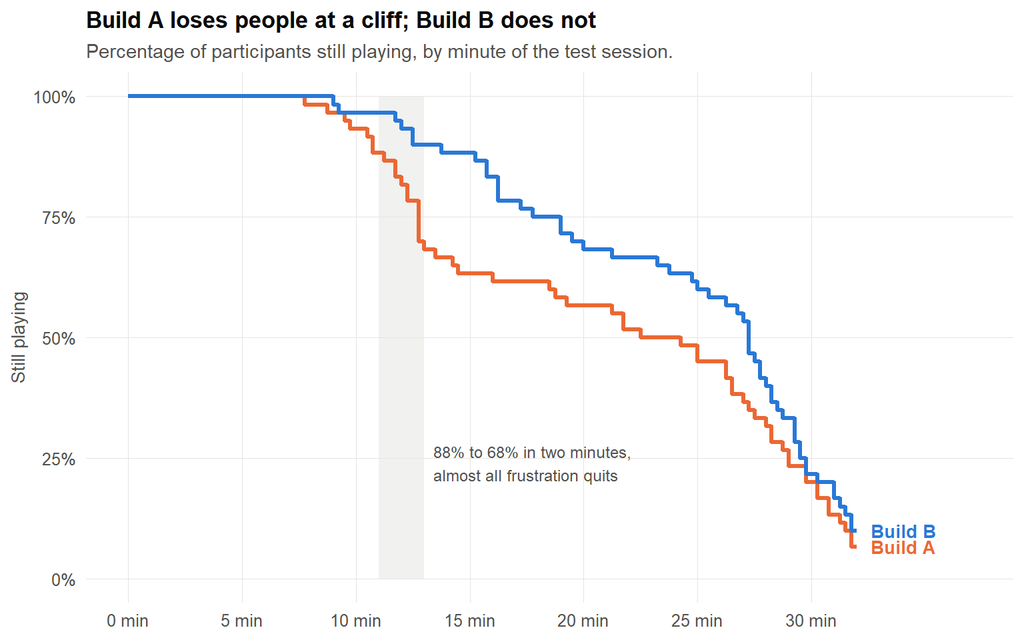

```r
# Check every quarter-minute of the 32-minute session.
minutes <- seq(0, 32, by = 0.25)

# For each build and each moment: what share of sessions were still going?
retention <- map_dfr(c("A", "B"), function(b) {
  lengths <- sessions %>% filter(build == b) %>% pull(session_minutes)
  tibble(build = b, minute = minutes,
         pct = map_dbl(minutes, ~ 100 * mean(lengths >= .x)))
})

ends <- retention %>% group_by(build) %>% slice_max(minute, n = 1)

ggplot(retention, aes(minute, pct, colour = build)) +
  # Shade minutes 11 to 13. That's where Build A loses its players.
  annotate("rect", xmin = 11, xmax = 13, ymin = 0, ymax = 100,
           fill = ink[["grid"]], alpha = 0.55) +
  annotate("text", x = 13.4, y = 24, hjust = 0, size = 3.2,
           colour = ink[["secondary"]],
           label = "88% to 68% in two minutes,\nalmost all frustration quits") +
  # Steps, not a smooth line: players leave at a moment, not gradually.
  geom_step(linewidth = 1.1, direction = "hv") +
  geom_text(data = ends, aes(label = paste0("Build ", build)),
            hjust = 0, nudge_x = 0.6, size = 3.6, fontface = "bold",
            show.legend = FALSE) +
  scale_colour_manual(values = build_pal) +
  scale_x_continuous(limits = c(0, 37), breaks = seq(0, 30, 5),
                     labels = function(x) paste0(x, " min")) +
  scale_y_continuous(limits = c(0, 100), labels = function(y) paste0(y, "%")) +
  labs(
    title    = "Build A loses people at a cliff; Build B does not",
    subtitle = "Percentage of participants still playing, by minute of the test session.",
    x = NULL, y = "Still playing"
  ) +
  theme_tb()
```

## View 6 — What players said, ranked by how badly it went

**Question: the survey has eight questions and 120 responses. Which one should we act on first?**

Eight averages tell you almost nothing, because a mean of 3.0 can mean everyone was indifferent or that half loved it and half hated it. A diverging bar chart splits each item at the neutral response: disagreement runs left, agreement runs right, and the items sort by the net.

The result is uncomfortable in the way real survey results usually are. The art is the best-rated thing in the game by a distance. The worst-rated item is whether players ever knew what they were supposed to be doing — the same thing that drives the cliff in View 5. People praise the visuals and quit over the design.

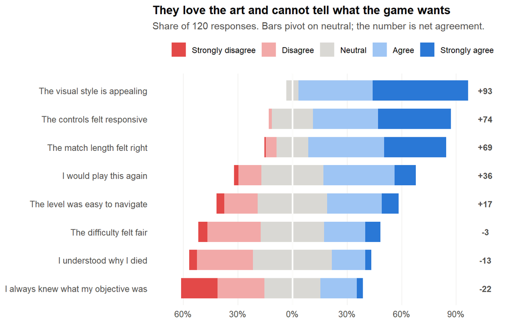

```r
item_label <- c(
  objective_clear     = "I always knew what my objective was",
  death_understood    = "I understood why I died",
  difficulty_fair     = "The difficulty felt fair",
  level_navigable     = "The level was easy to navigate",
  would_play_again    = "I would play this again",
  match_length        = "The match length felt right",
  controls_responsive = "The controls felt responsive",
  visual_style        = "The visual style is appealing"
)

resp_label <- c("Strongly disagree", "Disagree", "Neutral", "Agree", "Strongly agree")

# One row per answer, then the share of each rating for every question.
props <- survey %>%
  pivot_longer(-session_id, names_to = "item", values_to = "resp") %>%
  count(item, resp) %>%
  complete(item, resp = 1:5, fill = list(n = 0)) %>%
  group_by(item) %>% mutate(pct = 100 * n / sum(n)) %>% ungroup()

# Sort the questions by net agreement, agree minus disagree. Worst at the bottom.
ranking <- props %>%
  group_by(item) %>%
  summarise(net = sum(pct[resp >= 4]) - sum(pct[resp <= 2])) %>%
  arrange(net)

item_levels <- unname(item_label[ranking$item])

# Split the neutral answers in half, so each bar balances on zero.
as_bars <- function(d, sign) {
  d %>%
    mutate(signed = sign * if_else(resp == 3, pct / 2, pct),
           item   = factor(unname(item_label[item]), levels = item_levels),
           resp   = factor(resp_label[resp], levels = resp_label))
}

# Disagreement goes left, agreement goes right, strongest answers on the outside.
bars_neg <- props %>% filter(resp <= 3) %>% as_bars(-1)
bars_pos <- props %>% filter(resp >= 3) %>% as_bars(+1)

ranking <- ranking %>%
  mutate(item = factor(unname(item_label[item]), levels = item_levels))

ggplot(mapping = aes(signed, item, fill = resp)) +
  geom_col(data = bars_neg, width = 0.72, position = position_stack()) +
  geom_col(data = bars_pos, width = 0.72, position = position_stack(reverse = TRUE)) +
  geom_vline(xintercept = 0, colour = "#fcfcfb", linewidth = 0.9) +
  geom_text(data = ranking, aes(x = 106, y = item, label = sprintf("%+.0f", net)),
            inherit.aes = FALSE, size = 3.3, fontface = "bold",
            colour = ink[["secondary"]]) +
  scale_fill_manual(values = c("Strongly disagree" = "#e34948",
                               "Disagree"          = "#f2a9a8",
                               "Neutral"           = "#d9d8d4",
                               "Agree"             = "#9ec5f4",
                               "Strongly agree"    = "#2a78d6")) +
  # Zoom with coord_cartesian(), not scale limits. Limits quietly drop any
  # bar that pokes past the edge.
  scale_x_continuous(breaks = seq(-60, 90, 30),
                     labels = function(x) paste0(abs(x), "%")) +
  coord_cartesian(xlim = c(-68, 112)) +
  labs(
    title    = "They love the art and cannot tell what the game wants",
    subtitle = "Share of 120 responses. Bars pivot on neutral; the number is net agreement.",
    x = NULL, y = NULL, fill = NULL
  ) +
  theme_tb() +
  theme(legend.position = "top",
        legend.text     = element_text(size = 9),
        panel.grid.major.y = element_blank())
```

## View 7 — The frame-rate counter is lying to you

**Question: both builds average about 59 FPS. Testers say Build B stutters. Who is right?**

Both are. Average frame rate is a mean, and a mean is exactly the wrong summary for a quantity where the rare bad values are the entire user experience. Build B renders almost every frame slightly faster than Build A. It also renders one frame in every twenty-five — about twice a second — in 35 to 55 ms instead of 17, and only in one zone of the level: the corridor that View 8 identifies as the choke point.

The trace shows it. The table shows why the FPS readout missed it: the two builds are separated by 0.05 ms at the mean and by 20 ms at the 99th percentile.

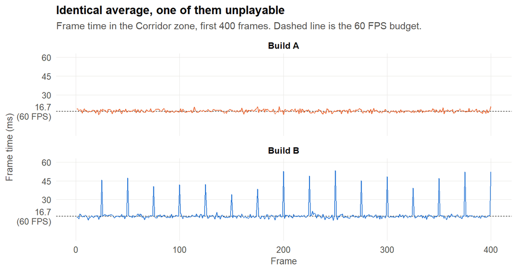

```r
# The first 400 frames of the Corridor, one panel per build.
ggplot(frame_times %>% filter(zone == "Corridor", frame <= 400),
       aes(frame, ms, colour = build)) +
  # Dashed line: the 60 FPS budget, 16.7 ms a frame.
  geom_hline(yintercept = 1000 / 60, linetype = "22",
             colour = ink[["secondary"]], linewidth = 0.4) +
  geom_line(linewidth = 0.45) +
  facet_wrap(~build, ncol = 1, labeller = labeller(build = function(b) paste("Build", b))) +
  scale_colour_manual(values = build_pal) +
  scale_y_continuous(limits = c(0, 60), breaks = c(1000/60, 30, 45, 60),
                     labels = c("16.7\n(60 FPS)", "30", "45", "60")) +
  labs(
    title    = "Identical average, one of them unplayable",
    subtitle = "Frame time in the Corridor zone, first 400 frames. Dashed line is the 60 FPS budget.",
    x = "Frame", y = "Frame time (ms)"
  ) +
  theme_tb() +
  theme(strip.text = element_text(face = "bold", colour = ink[["primary"]]))
```

```r
# The usual summaries side by side. Watch which columns finally tell the builds apart.
frame_times %>%
  group_by(Build = build) %>%
  summarise(
    `Mean FPS`     = round(1000 / mean(ms), 1),
    `Mean (ms)`    = round(mean(ms), 2),
    `Median (ms)`  = round(median(ms), 1),
    `95th (ms)`    = round(quantile(ms, 0.95), 1),
    `99th (ms)`    = round(quantile(ms, 0.99), 1),
    `Worst (ms)`   = round(max(ms), 1)
  ) %>%
  knitr::kable(caption = "Every column agrees the builds are the same until the last two.")
```

Every column agrees the builds are the same until the last two.

| Build | Mean FPS | Mean (ms) | Median (ms) | 95th (ms) | 99th (ms) | Worst (ms) |
| --- | --- | --- | --- | --- | --- | --- |
| A | 58.8 | 17.00 | 17.0 | 18.8 | 19.5 | 20.7 |
| B | 59.0 | 16.95 | 16.6 | 18.4 | 39.4 | 54.2 |

## View 8 — Where players actually stand

**Question: where are the choke points, the camping spots and the dead space?**

This is the figure that changes level layouts. The blue field is total time spent per square metre across the whole match. The moving dots are the eight players, one frame per second, coloured by whether they are moving, loitering or holding position. Dark blocks are cover; the block in the north-east is the raised gantry.

Press play, or drag the slider.

Three readings, all of them actionable:

```r
# How long players spent in each 2 m square of the map: the heat underneath.
gx_seq <- seq(1, 59, 2)
gy_seq <- seq(1, 39, 2)

field <- positions %>%
  mutate(gx = floor(x / 2) * 2 + 1, gy = floor(y / 2) * 2 + 1) %>%
  count(gx, gy) %>%
  complete(gx = gx_seq, gy = gy_seq, fill = list(n = 0)) %>%
  arrange(gy, gx)

z <- matrix(field$n, nrow = length(gy_seq), ncol = length(gx_seq), byrow = TRUE)

# The level's walls and raised areas, drawn as rectangles on top.
shapes <- pmap(level, function(block, xmin, xmax, ymin, ymax, kind) {
  list(type = "rect", x0 = xmin, x1 = xmax, y0 = ymin, y1 = ymax,
       fillcolor = if (kind == "elevated") "#6f6e6a" else "#2f2e2c",
       # The gantry is walkable, so keep it see-through: you can still
       # read the heat underneath.
       opacity = if (kind == "elevated") 0.35 else 0.92,
       line = list(width = 0), layer = "above")
})

# Start the animation at the first second where all three player states
# appear, so the legend is complete from the start.
first_full <- positions %>%
  group_by(t) %>% summarise(k = n_distinct(state)) %>%
  filter(k == 3) %>% slice_min(t) %>% pull(t)

# Every death, to mark with a red cross.
deaths <- positions %>% filter(event == "death")

# plotly makes it interactive: hover for detail, press play to watch the match.
plot_ly(height = 560) %>%
  add_heatmap(
    x = gx_seq, y = gy_seq, z = z, zmin = 0, zmax = 60,
    colorscale = list(c(0, "#fcfcfb"), c(0.25, "#cde2fb"),
                      c(0.6, "#5598e7"), c(1, "#104281")),
    showscale = TRUE, hoverinfo = "z",
    colorbar = list(title = "Seconds\nspent", len = 0.55, thickness = 12,
                    y = 0.72, ticksuffix = "  ")
  ) %>%
  add_markers(
    data = deaths, x = ~x, y = ~y, name = "Death",
    marker = list(symbol = "x", size = 11, color = "#e34948",
                  line = list(color = "#fcfcfb", width = 1)),
    text = ~paste0("death · ", player_id, " · t=", t, "s"), hoverinfo = "text"
  ) %>%
  add_markers(
    data = positions %>% filter(t >= first_full),
    x = ~x, y = ~y, frame = ~t, color = ~state,
    colors = c(Holding = pal[["orange"]], Loitering = pal[["aqua"]],
               Moving = pal[["blue"]]),
    marker = list(size = 13, line = list(color = "#fcfcfb", width = 2)),
    text = ~paste0(player_id, " · t=", t, "s · ", state),
    hoverinfo = "text"
  ) %>%
  layout(
    title  = list(text = "<b>One corridor carries the traffic and most of the deaths</b>",
                  x = 0, font = list(size = 14)),
    shapes = shapes,
    xaxis  = list(title = "x (m)", range = c(0, 60), constrain = "domain"),
    yaxis  = list(title = "y (m)", range = c(0, 40), scaleanchor = "x"),
    legend = list(orientation = "h", x = 0, y = 1.02, title = list(text = "")),
    margin = list(t = 80)
  ) %>%
  animation_opts(frame = 90, transition = 45, redraw = FALSE) %>%
  animation_slider(currentvalue = list(prefix = "t = ", suffix = " s"))
```

[interactive chart not shown]

### Following one player

The map above answers questions about the *level*. To ask questions about a *player* — did they learn the route, did they loop, did they ever leave their corner — you need to follow one of them.

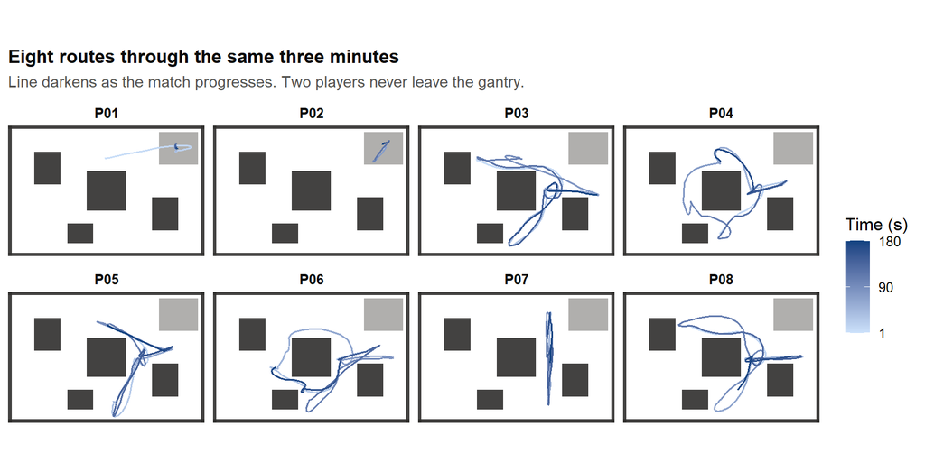

```r
# Walls and the raised gantry, split so they can be shaded differently.
walls <- level %>% filter(kind != "elevated")
raised <- level %>% filter(kind == "elevated")

ggplot() +
  geom_rect(data = walls, aes(xmin = xmin, xmax = xmax, ymin = ymin, ymax = ymax),
            fill = "#2f2e2c", alpha = 0.9) +
  geom_rect(data = raised, aes(xmin = xmin, xmax = xmax, ymin = ymin, ymax = ymax),
            fill = "#6f6e6a", alpha = 0.55) +
  # Each player's route, darkening as the match goes on.
  geom_path(data = positions, aes(x, y, colour = t), linewidth = 0.7) +
  # One small panel per player, so you can compare routes side by side.
  facet_wrap(~player_id, nrow = 2) +
  scale_colour_gradient(low = "#cde2fb", high = "#104281",
                        name = "Time (s)", breaks = c(1, 90, 180)) +
  coord_fixed(xlim = c(0, 60), ylim = c(0, 40), expand = FALSE) +
  labs(
    title    = "Eight routes through the same three minutes",
    subtitle = "Line darkens as the match progresses. Two players never leave the gantry.",
    x = NULL, y = NULL
  ) +
  theme_tb() +
  theme(axis.text         = element_blank(),
        panel.grid.major  = element_blank(),
        panel.grid.minor  = element_blank(),
        strip.text        = element_text(face = "bold", colour = ink[["primary"]]),
        legend.position   = "right",
        legend.key.height = unit(0.9, "lines"))
```

Now one player, animated, with the trail drawn behind them. Change `focus_player` to any ID from the panel above and re-run the chunk. The orange dots mark every second this player spent holding position, so you can see where they will stop before they get there.

```r
# Follow one player. Change this to any ID from P01 to P08.
focus_player <- "P06"

path <- positions %>% filter(player_id == focus_player) %>% arrange(t)

# For each second, every position so far. That's what makes the trail grow
# instead of jumping.
trail <- map_dfr(path$t, function(k) path %>% filter(t <= k) %>% mutate(f = k))

plot_ly(height = 560) %>%
  add_markers(
    data = path %>% filter(state == "Holding"), x = ~x, y = ~y,
    name = "Held position",
    marker = list(size = 7, color = pal[["orange"]], opacity = 0.7),
    text = ~paste0("holding · t=", t, "s"), hoverinfo = "text"
  ) %>%
  add_markers(
    data = path %>% slice(1), x = ~x, y = ~y, name = "Start",
    marker = list(symbol = "circle-open", size = 16, color = ink[["primary"]],
                  line = list(width = 2.5)),
    hoverinfo = "text", text = "start"
  ) %>%
  # The growing trail, then the player's current position on top.
  add_paths(
    data = trail, x = ~x, y = ~y, frame = ~f,
    line = list(color = pal[["blue"]], width = 2.5),
    opacity = 0.8, showlegend = FALSE, hoverinfo = "skip"
  ) %>%
  add_markers(
    data = path, x = ~x, y = ~y, frame = ~t,
    marker = list(size = 16, color = pal[["blue"]],
                  line = list(color = "#fcfcfb", width = 2.5)),
    showlegend = FALSE,
    text = ~paste0(focus_player, " · t=", t, "s · ", state), hoverinfo = "text"
  ) %>%
  layout(
    title  = list(text = paste0("<b>", focus_player, "'s route through the match</b>"),
                  x = 0, font = list(size = 14)),
    shapes = shapes,
    xaxis  = list(title = "x (m)", range = c(0, 60), constrain = "domain"),
    yaxis  = list(title = "y (m)", range = c(0, 40), scaleanchor = "x"),
    legend = list(orientation = "h", x = 0, y = 1.02, title = list(text = "")),
    margin = list(t = 80)
  ) %>%
  animation_opts(frame = 70, transition = 0, redraw = FALSE) %>%
  animation_slider(currentvalue = list(prefix = "t = ", suffix = " s"))
```

[interactive chart not shown]

## What each view cost

| View | Chart type | Lines of R | Skills it needs |
| --- | --- | --- | --- |
| 1 | Interactive table | 14 | Reading data; selecting and renaming columns |
| 2 | Violin with boxplot | 14 | Describing distributions |
| 3 | Radar small multiples | 34 | Reshaping data; grouped summaries |
| 4 | Correlogram | 35 | Relationships between variables |
| 5 | Retention step curve | 27 | Building a summary from scratch; annotation |
| 6 | Diverging Likert bars | 55 | Reshaping; ordering by a computed value |
| 7 | Frame-time trace + summary table | 16 + 11 | Filtering; percentiles; rendered tables |
| 8 | Animated position map | 53 | Grouping, counting, interactive output |
| 8b | Route small multiples | 24 | Drawing paths; faceting by player |
| 8b | Animated single-player trail | 39 | Filtering to one case; building frames |

None of this is difficult, and most of the length in Views 3 onwards is labelling and styling rather than analysis. All of it is repeatable: the same code runs unchanged on next week’s build, which is the real reason to write analysis as code rather than clicking through a spreadsheet.

The rest of these notes teach you the parts, in order, starting with the question that matters most: **what are you actually trying to find out?**